# Lab 2

Author

Your Name Here

Published

April 8, 2026

# 1 Workflow for Lab 02

The lab instructions can be found [here](https://stevenbedrick.github.io/data-vis-labs-2026/02-moma.html); we will work through its contents together. You will use this Quarto file as your workspace, and its rendered HTML file as the final deliverable in Sakai. Don’t forget to update the “author” metadata field at the top of the file!

# 2 Start by Loading Libraries

# 3 Know Your Data

```r
artworks_clean <- read.csv(here('data','artworks-cleaned.csv'))
```

# 4 What is the first painting acquired by MoMA? Which year? Which artist? What title?

```r
artworks_clean %>% arrange(year_acquired) %>% glimpse()
```

```
Rows: 2,253
Columns: 23
$ title             <chr> "House by the Railroad", "Seated Nude", "Daylight Sa…
$ artist            <chr> "Edward Hopper", "Bernard Karfiol", "Pierre Roy", "P…
$ artist_bio        <chr> "(American, 1882–1967)", "(American, born Hungary. 1…
$ artist_birth_year <int> 1882, 1886, 1880, 1889, 1891, 1839, 1839, 1839, 1839…
$ artist_death_year <int> 1967, 1952, 1950, 1930, 1969, 1906, 1906, 1906, 1906…
$ num_artists       <int> 1, 1, 1, 1, 1, 1, 1, 1, 1, 1, 1, 1, 1, 1, 1, 1, 1, 1…
$ n_female_artists  <int> 0, 0, 0, 0, 0, 0, 0, 0, 0, 0, 0, 0, 0, 0, 0, 0, 0, 0…
$ n_male_artists    <int> 1, 1, 1, 1, 1, 1, 1, 1, 1, 1, 1, 1, 1, 1, 1, 1, 1, 1…
$ artist_gender     <chr> "Male", "Male", "Male", "Male", "Male", "Male", "Mal…
$ year_acquired     <int> 1930, 1930, 1931, 1931, 1932, 1934, 1934, 1934, 1934…
$ year_created      <int> 1925, 1929, 1929, 1926, 1926, 1885, 1897, 1902, 1895…
$ circumference_cm  <lgl> NA, NA, NA, NA, NA, NA, NA, NA, NA, NA, NA, NA, NA, …
$ depth_cm          <dbl> NA, NA, NA, NA, NA, NA, NA, NA, NA, NA, NA, NA, NA, …
$ diameter_cm       <lgl> NA, NA, NA, NA, NA, NA, NA, NA, NA, NA, NA, NA, NA, …
$ height_cm         <dbl> 61.0, 101.6, 54.6, 35.6, 149.2, 127.0, 81.3, 60.6, 6…
$ length_cm         <lgl> NA, NA, NA, NA, NA, NA, NA, NA, NA, NA, NA, NA, NA, …
$ width_cm          <dbl> 73.7000, 76.2000, 38.1000, 50.8000, 99.0602, 96.8000…
$ seat_height_cm    <lgl> NA, NA, NA, NA, NA, NA, NA, NA, NA, NA, NA, NA, NA, …
$ purchase          <lgl> FALSE, FALSE, FALSE, FALSE, FALSE, FALSE, FALSE, FAL…
$ gift              <lgl> FALSE, TRUE, TRUE, TRUE, TRUE, FALSE, FALSE, FALSE, …
$ exchange          <lgl> FALSE, FALSE, FALSE, FALSE, FALSE, FALSE, FALSE, FAL…
$ classification    <chr> "Painting", "Painting", "Painting", "Painting", "Pai…
$ department        <chr> "Painting & Sculpture", "Painting & Sculpture", "Pai…
```

The first painting acquired by MoMA is “House by the Railroad” by Edward Hopper. It was acquired in 1930

## 4.1 How Many Paintings?

There are 2253 paintings in moma, each painting has 23 variables

## 4.2 What is the first painting that was acquired?

“House by the Railroad” by Edward Hopper

## 4.3 What is the oldest painting?

```r
artworks_clean %>% arrange(year_created) %>% glimpse()
```

```
Rows: 2,253
Columns: 23
$ title             <chr> "Landscape at Daybreak", "Apache (Man on Horseback)"…
$ artist            <chr> "Odilon Redon", "Odilon Redon", "Odilon Redon", "Odi…
$ artist_bio        <chr> "(French, 1840–1916)", "(French, 1840–1916)", "(Fren…
$ artist_birth_year <int> 1840, 1840, 1840, 1840, 1840, 1840, 1840, 1839, 1839…
$ artist_death_year <int> 1916, 1916, 1916, 1916, 1916, 1916, 1916, 1906, 1906…
$ num_artists       <int> 1, 1, 1, 1, 1, 1, 1, 1, 1, 1, 1, 1, 1, 1, 1, 1, 1, 1…
$ n_female_artists  <int> 0, 0, 0, 0, 0, 0, 0, 0, 0, 0, 0, 0, 0, 0, 0, 0, 0, 0…
$ n_male_artists    <int> 1, 1, 1, 1, 1, 1, 1, 1, 1, 1, 1, 1, 1, 1, 1, 1, 1, 1…
$ artist_gender     <chr> "Male", "Male", "Male", "Male", "Male", "Male", "Mal…
$ year_acquired     <int> 2000, 2000, 2000, 2000, 2000, 2000, 2000, 1991, 1959…
$ year_created      <int> 1872, 1875, 1875, 1875, 1875, 1875, 1875, 1879, 1879…
$ circumference_cm  <lgl> NA, NA, NA, NA, NA, NA, NA, NA, NA, NA, NA, NA, NA, …
$ depth_cm          <dbl> NA, NA, NA, NA, NA, NA, NA, NA, NA, NA, NA, NA, NA, …
$ diameter_cm       <lgl> NA, NA, NA, NA, NA, NA, NA, NA, NA, NA, NA, NA, NA, …
$ height_cm         <dbl> 38.4000, 25.0826, 23.1775, 16.8275, 24.7650, 25.0826…
$ length_cm         <lgl> NA, NA, NA, NA, NA, NA, NA, NA, NA, NA, NA, NA, NA, …
$ width_cm          <dbl> 55.3000, 32.4000, 32.4000, 21.9075, 33.0201, 32.7026…
$ seat_height_cm    <lgl> NA, NA, NA, NA, NA, NA, NA, NA, NA, NA, NA, NA, NA, …
$ purchase          <lgl> FALSE, FALSE, FALSE, FALSE, FALSE, FALSE, FALSE, FAL…
$ gift              <lgl> TRUE, TRUE, TRUE, TRUE, TRUE, TRUE, TRUE, TRUE, FALS…
$ exchange          <lgl> FALSE, FALSE, FALSE, FALSE, FALSE, FALSE, FALSE, FAL…
$ classification    <chr> "Painting", "Painting", "Painting", "Painting", "Pai…
$ department        <chr> "Painting & Sculpture", "Painting & Sculpture", "Pai…
```

The oldest painting at MoMA is “Landscape at Daybreak” by Odilon Redon

## 4.4 How many artists?

```r
artworks_clean %>% distinct(artist) %>% nrow()
```

```
[1] 989
```

There are 989 distinct artists

## 4.5 Which artist has the most paintings?

```r
artworks_clean %>% group_by(artist) %>% tally() %>% arrange(desc(n))
```

```
# A tibble: 989 × 2
   artist               n
   <chr>            <int>
 1 Pablo Picasso       55
 2 Henri Matisse       32
 3 On Kawara           32
 4 Jacob Lawrence      30
 5 Batiste Madalena    25
 6 Jean Dubuffet       25
 7 Odilon Redon        25
 8 Ben Vautier         24
 9 Frank Stella        23
10 Philip Guston       23
# ℹ 979 more rows
```

The artist with the most paintings is Pablo Picasso with 55 paintings

## 4.6 How many paintings, by gender?

```r
artworks_clean %>% group_by(artist_gender) %>% tally()
```

```
# A tibble: 3 × 2
  artist_gender     n
  <chr>         <int>
1 Female          252
2 Male           1991
3 <NA>             10
```

Female artists have 252 paintings and Male artists have 1991 paintings

## 4.7 How many artists, by gender?

```r
artworks_clean %>% select(artist,artist_gender) %>% distinct() %>% group_by(artist_gender) %>% tally()
```

```
# A tibble: 3 × 2
  artist_gender     n
  <chr>         <int>
1 Female          143
2 Male            837
3 <NA>              9
```

There are 143 female artists and 837 male artists

## 4.8 In which years were the most paintings in the collection *acquired*?

```r
artworks_clean %>% count(year_acquired,sort=TRUE) %>% glimpse()
```

```
Rows: 88
Columns: 2
$ year_acquired <int> 1985, 1942, 1979, 1991, 2005, 1967, 2008, 1961, 1969, 19…
$ n             <int> 86, 71, 71, 67, 67, 65, 55, 45, 45, 42, 41, 39, 39, 38, …
```

Most of the paintings were acquired in 1985

## 4.9 In which years were the most paintings in the collection *created*?

```r
artworks_clean %>% count(year_created,sort=TRUE) %>% glimpse()
```

```
Rows: 139
Columns: 2
$ year_created <int> 1977, 1940, 1964, 1961, 1962, 1963, 1959, 1968, 1960, 191…
$ n            <int> 57, 56, 56, 50, 49, 44, 42, 40, 39, 37, 37, 36, 36, 34, 3…
```

```r
artworks_clean %>% filter(artist_gender == "Female" & num_artists == 1) %>% arrange(year_acquired) %>% glimpse()
```

```
Rows: 252
Columns: 23
$ title             <chr> "Landscape, 47", "Shack", "Hopscotch", "Shadows with…
$ artist            <chr> "Natalia Goncharova", "Loren MacIver", "Loren MacIve…
$ artist_bio        <chr> "(Russian, 1881–1962)", "(American, 1909–1998)", "(A…
$ artist_birth_year <int> 1881, 1909, 1909, 1907, 1894, 1896, 1907, 1903, 1902…
$ artist_death_year <int> 1962, 1998, 1998, 1971, 1958, 1968, 1971, 1999, 1988…
$ num_artists       <int> 1, 1, 1, 1, 1, 1, 1, 1, 1, 1, 1, 1, 1, 1, 1, 1, 1, 1…
$ n_female_artists  <int> 1, 1, 1, 1, 1, 1, 1, 1, 1, 1, 1, 1, 1, 1, 1, 1, 1, 1…
$ n_male_artists    <int> 0, 0, 0, 0, 0, 0, 0, 0, 0, 0, 0, 0, 0, 0, 0, 0, 0, 0…
$ artist_gender     <chr> "Female", "Female", "Female", "Female", "Female", "F…
$ year_acquired     <int> 1937, 1938, 1940, 1941, 1941, 1942, 1942, 1942, 1942…
$ year_created      <int> 1912, 1934, 1940, 1940, 1921, 1938, 1942, 1942, 1942…
$ circumference_cm  <lgl> NA, NA, NA, NA, NA, NA, NA, NA, NA, NA, NA, NA, NA, …
$ depth_cm          <dbl> NA, NA, NA, 6.0, NA, NA, NA, NA, NA, NA, NA, NA, NA,…
$ diameter_cm       <lgl> NA, NA, NA, NA, NA, NA, NA, NA, NA, NA, NA, NA, NA, …
$ height_cm         <dbl> 54.6, 51.1, 68.6, 41.9, 141.6, 69.3, 65.7, 40.3, 93.…
$ length_cm         <lgl> NA, NA, NA, NA, NA, NA, NA, NA, NA, NA, NA, NA, NA, …
$ width_cm          <dbl> 46.7, 61.0, 91.1, 34.6, 88.3, 85.1, 55.6, 66.4, 72.7…
$ seat_height_cm    <lgl> NA, NA, NA, NA, NA, NA, NA, NA, NA, NA, NA, NA, NA, …
$ purchase          <lgl> FALSE, FALSE, TRUE, FALSE, FALSE, FALSE, FALSE, FALS…
$ gift              <lgl> TRUE, TRUE, FALSE, TRUE, FALSE, FALSE, TRUE, TRUE, F…
$ exchange          <lgl> FALSE, FALSE, FALSE, FALSE, FALSE, FALSE, FALSE, FAL…
$ classification    <chr> "Painting", "Painting", "Painting", "Painting", "Pai…
$ department        <chr> "Painting & Sculpture", "Painting & Sculpture", "Pai…
```

The first painting acquired by a solo female artist is “Landscape, 47” by Natalia Goncharova

# 5 Basic Plotting!

## 5.1 Year painted vs. year acquired

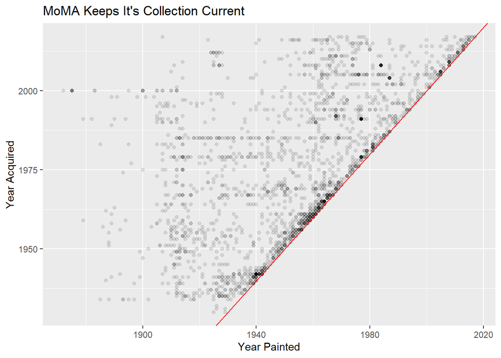

```r
ggplot(artworks_clean,aes(year_created,year_acquired)) +
  geom_point(na.rm=TRUE,alpha = 0.1) +
  geom_abline(intercept=c(0,0),colour="red") +
  labs(x="Year Painted",y="Year Acquired",title = "MoMA Keeps It's Collection Current")
```

## 5.2 Faceting by gender

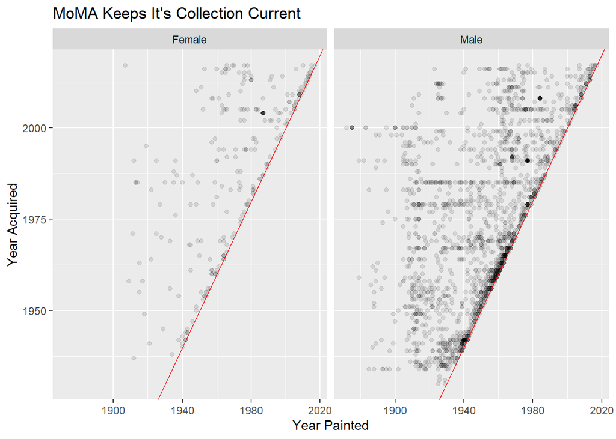

```r
artworks_clean %>% filter(num_artists == 1) %>%
  ggplot(aes(year_created,year_acquired)) +
  geom_point(na.rm=TRUE,alpha = 0.1) +
  geom_abline(intercept=c(0,0),colour="red") +
  labs(x="Year Painted",y="Year Acquired",title = "MoMA Keeps It's Collection Current") + facet_wrap(~artist_gender)
```

# 6 Exploring Painting Dimensions

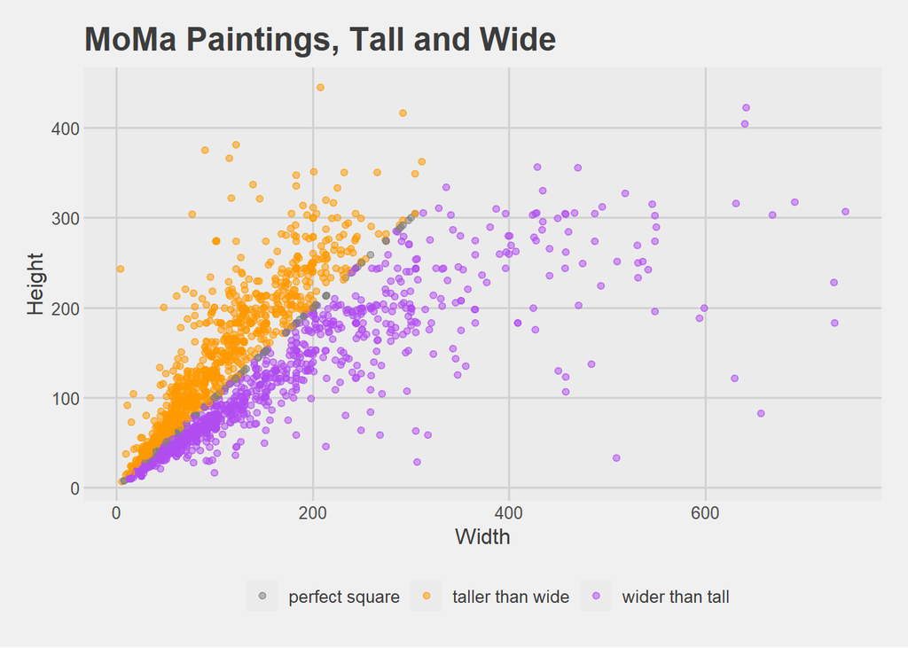

```r
mona_dim <- artworks_clean %>%
  filter(height_cm < 600 & width_cm < 760) %>%
  mutate(
    hw_ratio = height_cm / width_cm,
    hw_cat = case_when(
      hw_ratio > 1 ~ "taller than wide",
      hw_ratio < 1 ~ "wider than tall",
      hw_ratio == 1 ~ "perfect square"
    )
  )

ggplot(mona_dim,aes(x=width_cm,y=height_cm,colour = hw_cat)) +
  geom_point(alpha=0.5) +
  labs(x="Width",y="Height",title="MoMa Paintings, Tall and Wide") +
    scale_colour_manual(name = "",
                      values = c("gray50", "#FF9900", "#B14CF0"))+
  theme_fivethirtyeight() +
  theme(axis.title = element_text())
```

## 6.1 Challenge #4

## 6.2 Different colors

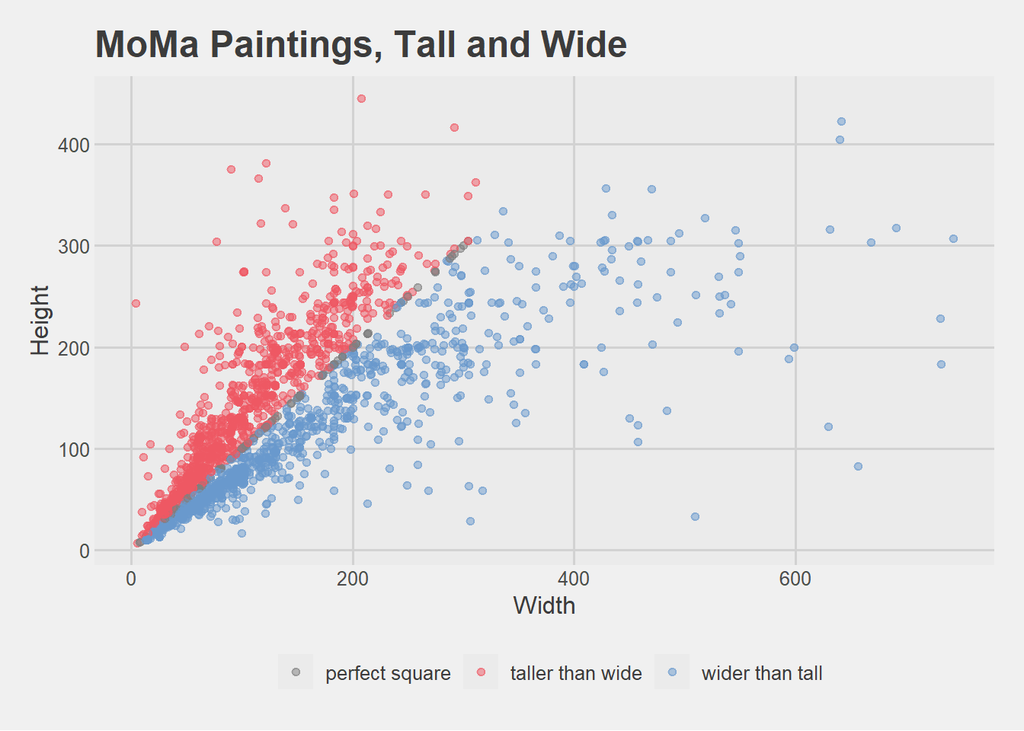

```r
ggplot(mona_dim,aes(x=width_cm,y=height_cm,colour = hw_cat)) +
  geom_point(alpha=0.5) +
  labs(x="Width",y="Height",title="MoMa Paintings, Tall and Wide") +
  theme_fivethirtyeight() +
  theme(axis.title = element_text()) +
  scale_colour_manual(
    name = "",
    values = c("gray50", "#ee5863", "#6999cd"))
```

## 6.3 Experimenting with `geom_annotate()`

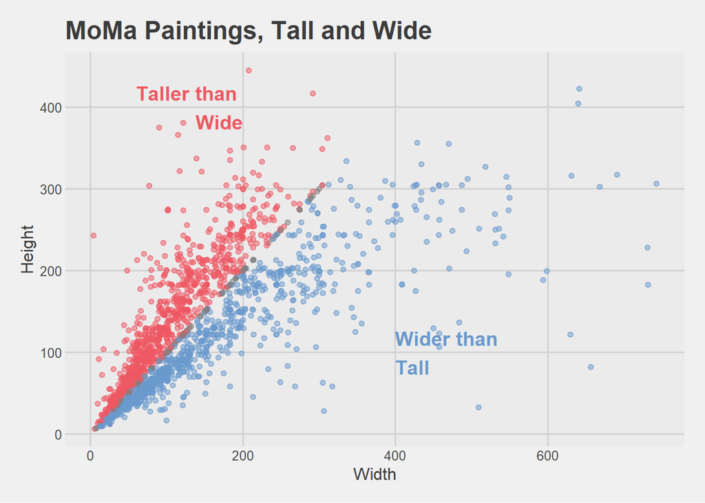

```r
ggplot(mona_dim,aes(x=width_cm,y=height_cm,colour = hw_cat)) +
  geom_point(alpha=0.5,show.legend=FALSE) +
  labs(x="Width",y="Height",title="MoMa Paintings, Tall and Wide") +
  theme_fivethirtyeight() +
  theme(axis.title = element_text()) +
  scale_colour_manual(
    name = "",
    values = c("gray50", "#ee5863", "#6999cd")) +
  annotate(label = "Taller than \nWide",x=200,y=400,geom = "text",colour = "#ee5863",
           size = 5, family = "Lato", hjust = 1, fontface = 2) +
    annotate(label = "Wider than \nTall",x=400,y=100,geom = "text",colour = "#6999cd",
           size = 5, family = "Lato", hjust = 0, fontface = 2)
```

# 7 Challenge #5, on your own!

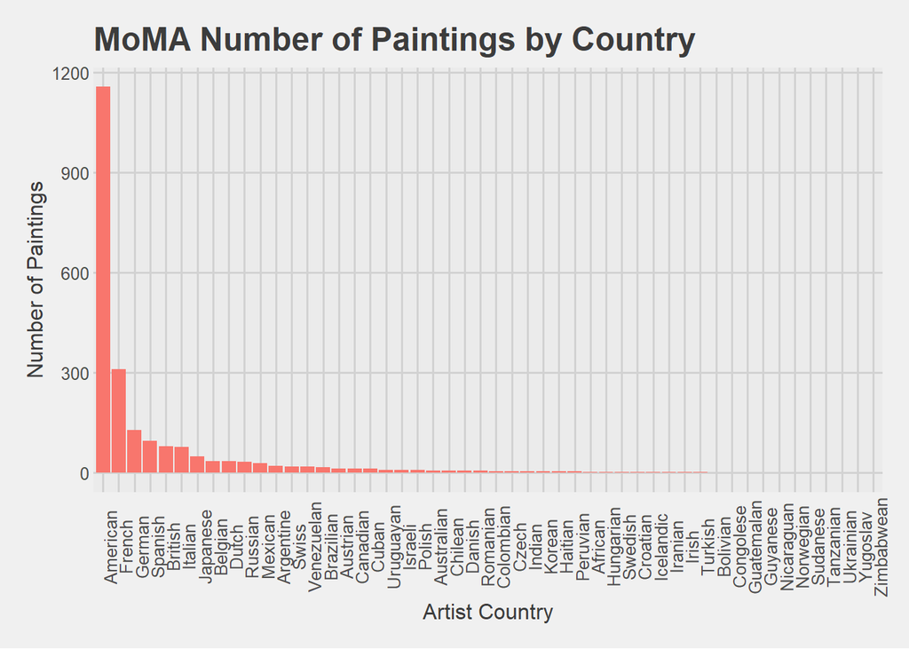

```r
moma_origin <- artworks_clean %>%
  mutate(
    #extracting country from artist_bio
    artist_country = str_extract(pattern = "[A-Za-z]*?(?=,)",string = artist_bio)
  ) %>% filter(!(artist_country %in% c("origin","")) & !is.na(artist_country)) %>%
  group_by(artist_country) %>%
  summarize(
    num_paintings = n()
  ) %>% arrange(desc(num_paintings))


ggplot(moma_origin,aes(x= reorder(artist_country,-num_paintings),y = num_paintings,fill = "#ee5863")) +
  geom_col() +
  theme_fivethirtyeight() +
  labs(x = "Artist Country",y="Number of Paintings",title = "MoMA Number of Paintings by Country") +
  theme(axis.title = element_text(),axis.text.x = element_text(angle=90),legend.position = "none")
```

From this plot we can see how often different countries are represented at MoMA. This plot makes sense because the MoMA is located in America so most of the donations would be from Americans which is why American is over represented compared to other countries.